# Simulations

Peter Edelsbrunner, Fabian Dablander

2015-07-23

## Vignette Overview

This gives an overview of the simulations we presented at [ECPA13](http://www.ecpa13.com/). In our talk (see the respective vignette), we reviewed the practices of Rasch modeling in the literature on scientific thinking. We found that researchers most strongly rely on item infit statistics to assess the fit of the Rasch model. These infit statistics have been criticised for quite some time now (see for example Kreiner & Christensen, 2013). They assess the fit on an item-level, assuming that the Rasch model holds globally - which rarely is tested in the literature. The simulations below show that sole reliance on infit statistics is inappropriate. Instead we draw attention to several alternative model tests, all of which have been implemented in the free and open source software R.

First, we looked at how infit statistics behave when the Rasch model is true. It turns out that, contrary to the statistically inconsistent p-values, with increasing sample and item size no items would be removed.

Second, we looked at how they behave when equal item discrimination is violated. We found that one would remove a few items (as is common practice in the literature), depending on sample and item size. Crucially, using this reasoning, one would never reject the Rasch model, only items. Tautologically, researchers then conclude that, based on the fit of the Rasch model (assessed only through infit statistics) after removing items, scientific thinking is a unidimensional construct. Theoretically, this is unsound because one penetrates the item so long until the Rasch model fits; it is inadequate to subsequently claim that scientific thinking is a unidimensional construct.

In the third simulation, we looked at theoretical models that researchers have about scientific thinking. Most of the time, scientific thinking is assumed to be three to five dimensional, so we simulated from a correlated four dimensional factor structure. How do item infit statistics respond to such a crucial violation of the Rasch model? Not at all! Actually, not a single item (based on the common cutoff .8 - 1.2) would be removed.

In conclusion, we found that current practices are unsound, incoherent, and reductionist. We suggest a suite of tests researchers might employ to adequately assess the fit of the Rasch model. We further suggest that researchers match their theoretical models with their statistical ones. Importantly, we conjecture that solely relying on the proprietory software ConQuest (all research groups used this software to fit and “test” their models) limits the statistical possibilities and narrows theoretical thinking. We suggest using the free, open-source statistical software R, in which all of the tests mentioned in the last section are implemented.

## Simulation Parameters

```r
library('eRm')
library('lattice')
library('simrasch')

items <- c(12, 24, 60, 120) # number of items
n <- c(150, 300, 500, 1000) # number of participants
weights <- diag(.5, 4, 4) # item loadings on each factor
sigma <- matrix(c(1, 0.6, 0.5, 0.4, # factor loadings
                  0.6, 1, 0.7, 0.4, # for a theoretically plausible
                  0.5, 0.7, 1, 0.3, # 4-dimensional model of scientific reasoning
                  0.4, 0.4, 0.3, 1), 4)
```

## Simulation specification

```r
# no violation
sim_rasch <- sim(n, items, 1000, sim.rasch, parallel = TRUE, cores = 4)

# violation of equal item discrimination
sim_2pl1 <- sim(n, items, 1000, sim.2pl, .1, parallel = TRUE, cores = 4)
sim_2pl3 <- sim(n, items, 1000, sim.2pl, .3, parallel = TRUE, cores = 4)
sim_2pl5 <- sim(n, items, 1000, sim.2pl, .5, parallel = TRUE, cores = 4)

# assing fit of Rasch model using Andersen's LR test
# after removing items based on infit (example call for items = 120, n = 1000)
sim_rem <- simrem(1000, 120, 1000, sim.2pl, .5, cores = 4)

# violation of unidimensionality
sim_mult <- sim(n, items, 1000, sim.xdim,
                Sigma = sigma, weights = weights, parallel = TRUE, cores = 4)
```

## Results

Because running this will take considerable amounts of time, we have included the results in this package. Note that the summarise function is a convenience function that stores the results of the compute_err from the package simrasch into a data.frame. The column **pvalue** and **infit** do not actually describe p-values nor infit statistics, but are percentages about how often an item would be rejected based on the p-value or infit statistics, respectively.

```r
data(sim_2pl1, sim_2pl3, sim_2pl5, sim_rasch, sim_mult, sim_removal)
```

Below we look at how the itemfit statistics (infit, standardized p-values) behave under various model misspecifications, and once when the true model is really the Rasch model.

## True model: Rasch

```r
sm_rasch <- summarize(sim_rasch)
sm_rasch
```

```
##    sims    n items  pval infit   simtype violation
## 1     0  150    12 0.065 0.020 sim.rasch     rasch
## 2     0  150    24 0.072 0.008 sim.rasch     rasch
## 3     0  150    60 0.070 0.004 sim.rasch     rasch
## 4     0  150   120 0.069 0.003 sim.rasch     rasch
## 5     0  300    12 0.050 0.004 sim.rasch     rasch
## 6     0  300    24 0.065 0.000 sim.rasch     rasch
## 7     0  300    60 0.067 0.000 sim.rasch     rasch
## 8     0  300   120 0.066 0.000 sim.rasch     rasch
## 9     0  500    12 0.041 0.001 sim.rasch     rasch
## 10    0  500    24 0.059 0.000 sim.rasch     rasch
## 11    0  500    60 0.063 0.000 sim.rasch     rasch
## 12    0  500   120 0.064 0.000 sim.rasch     rasch
## 13    0 1000    12 0.026 0.001 sim.rasch     rasch
## 14    0 1000    24 0.050 0.000 sim.rasch     rasch
## 15    0 1000    60 0.058 0.000 sim.rasch     rasch
## 16    0 1000   120 0.060 0.000 sim.rasch     rasch
```

```r
processed <- data.frame(violation = rep(c('pval', 'infit'), each = nrow(sm_rasch)),
                        reject = c(sm_rasch$pval, sm_rasch$infit), n = rep(sm_rasch$n, 2),
                        items = rep(sm_rasch$items, 2))
visualize(processed, ylim = c(0, .3))
```

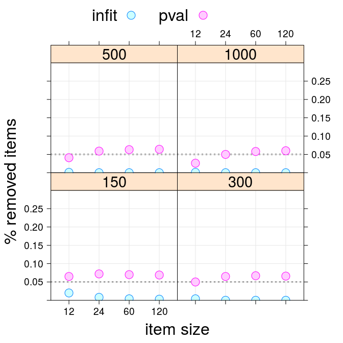

When the Rasch model is the data generating model, itemfit statistics using the cutoff of .8 and 1.2 are reasonably good in their item removal suggestions. With increasing sample size the number of items removed goes to zero. It seems that infit statistics are what is called **consistent**. In the limit, they will lead to the correct conclusion; at least when the Rasch model really is true. Standardized p-values, on the other hand, do not show this asymptotically correct behavior; p-values are inconsistent (with $\alpha$% errors).

# I. Violation: Item discrimination

## Specific example

In the specific example below, the item discrimination parameters were drawn from a lognormal distribution with $\mu = 0$ and $\sigma = .5$.

```r
dat <- sim.2pl(1000, 60, discrim = .5)
mrasch <- RM(dat)
pp <- person.parameter(mrasch)
eRm::itemfit(pp)
```

```
##
## Itemfit Statistics:
##        Chisq  df p-value Outfit MSQ Infit MSQ Outfit t Infit t
## I1  1061.701 999   0.082      1.062     1.017     0.95    0.48
## I2   929.263 999   0.943      0.929     0.945    -1.79   -2.09
## I3   899.328 999   0.989      0.899     0.958    -1.25   -0.91
## I4   823.494 999   1.000      0.823     0.888    -2.27   -2.58
## I5   946.613 999   0.881      0.947     0.961    -1.13   -1.36
## I6   841.067 999   1.000      0.841     0.875    -3.78   -4.70
## I7  1101.065 999   0.013      1.101     1.084     2.11    2.78
## I8   834.253 999   1.000      0.834     0.978    -1.39   -0.30
## I9   862.905 999   0.999      0.863     0.913    -2.93   -2.91
## I10 1293.048 999   0.000      1.293     1.198     6.72    6.98
## I11 1043.017 999   0.162      1.043     1.032     1.12    1.23
## I12  579.353 999   1.000      0.579     0.803    -4.31   -3.38
## I13 1031.876 999   0.229      1.032     1.019     0.80    0.72
## I14  985.160 999   0.616      0.985     1.015    -0.18    0.37
## I15  969.586 999   0.742      0.970     0.992    -0.62   -0.25
## I16 1427.733 999   0.000      1.428     1.180     6.37    4.97
## I17  995.741 999   0.523      0.996     0.980    -0.01   -0.34
## I18  899.690 999   0.989      0.900     0.926    -1.38   -1.78
## I19  837.760 999   1.000      0.838     0.876    -4.45   -4.98
## I20  615.328 999   1.000      0.615     0.846    -2.81   -1.86
## I21  700.834 999   1.000      0.701     0.753    -8.60  -10.31
## I22  938.031 999   0.916      0.938     1.004    -0.63    0.09
## I23  843.876 999   1.000      0.844     0.926    -2.14   -1.77
## I24  835.409 999   1.000      0.835     0.911    -1.58   -1.52
## I25 1083.474 999   0.032      1.083     1.064     1.41    1.80
## I26 1301.669 999   0.000      1.302     1.159     5.90    5.27
## I27 1116.247 999   0.006      1.116     1.072     2.82    2.71
## I28 1019.970 999   0.315      1.020     1.007     0.53    0.29
## I29 1051.358 999   0.122      1.051     0.997     0.69   -0.05
## I30 1127.941 999   0.003      1.128     1.072     2.97    2.66
## I31  874.030 999   0.998      0.874     0.923    -3.17   -2.87
## I32 1161.652 999   0.000      1.162     1.098     4.05    3.71
## I33  939.807 999   0.909      0.940     0.980    -1.18   -0.65
## I34  500.889 999   1.000      0.501     0.751    -5.66   -4.53
## I35  756.791 999   1.000      0.757     0.845    -4.00   -4.24
## I36 1205.163 999   0.000      1.205     1.167     5.00    6.17
## I37 1113.106 999   0.007      1.113     1.048     2.88    1.85
```

[output cut: 8 more lines]

```
## I46 1061.689 999   0.082      1.062     1.030     1.15    0.92
## I47  952.897 999   0.849      0.953     0.971    -1.17   -1.11
## I48  896.657 999   0.991      0.897     0.937    -2.73   -2.43
## I49  939.616 999   0.910      0.940     0.955    -1.56   -1.73
## I50  712.617 999   1.000      0.713     0.789    -6.57   -7.45
## I51 1063.448 999   0.077      1.063     1.027     0.58    0.45
## I52  867.710 999   0.999      0.868     0.912    -3.62   -3.50
## I53 1144.819 999   0.001      1.145     1.072     2.75    2.25
## I54 1031.840 999   0.229      1.032     1.010     0.70    0.36
## I55 1186.938 999   0.000      1.187     1.004     1.24    0.07
## I56 1304.773 999   0.000      1.305     1.206     7.33    7.54
## I57 1088.506 999   0.025      1.089     1.052     0.77    0.81
## I58 1000.497 999   0.481      1.000     1.025     0.03    0.74
## I59 1133.265 999   0.002      1.133     1.075     3.38    2.86
## I60 1222.191 999   0.000      1.222     1.142     5.47    5.30
```

## Simulation results

```r
sm_pl <- rbind(summarize(sim_2pl1), summarize(sim_2pl3), summarize(sim_2pl5))
visualize(sm_pl, ylim  = c(0, .3))
```

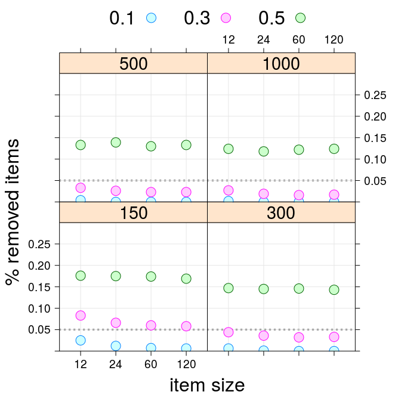

In this simulation, the item discriminations are drawn from a lognormal distribution with $\mu = 0$ and $\sigma = x$, where in our simulations x was either .1, .3, or .5.

Intriguingly, one can not really conclude anything at this point. One reasoning is that the items are no good, say because of their formulation, and thus need to be removed; or the Rasch model simply is inadequate. The different conclusions nicely embody the difference between the two “Rasch schools”, one applied, one theoretical. The fundamental problem is that one cannot make theoretical claims based on such “applied” model fitting procedures.

Notice that with $\sigma = .1$, the bias is too small and the Rasch model actually holds (we checked this using the model comparison procedure below).

## Further Simulations

What happens if we remove items based on infit statistics and then assess the fit of the Rasch model. Does the Rasch model now hold? Simple simulations based on the Andersen Likelihood Ratio test show that this is not at all the case! Even after brutal removal of items, the Rasch model does not hold:

```r
library('dplyr')
processed <- sim_removal %>%
             group_by(n, items, model, violation) %>%
             summarise(reject = mean(pvals <= .05)) %>% data.frame

processed
```

```
##       n items model violation reject
## 1   150    12 rasch     rasch  0.042
## 2   150    12   2PL       0.3  0.136
## 3   150    12   2PL       0.5  0.183
## 4   150    24 rasch     rasch  0.038
## 5   150    24   2PL       0.3  0.313
## 6   150    24   2PL       0.5  0.507
## 7   150    60 rasch     rasch  0.057
## 8   150    60   2PL       0.3  0.722
## 9   150    60   2PL       0.5  0.887
## 10  150   120 rasch     rasch  0.044
## 11  150   120   2PL       0.3  0.957
## 12  150   120   2PL       0.5  0.996
## 13  300    12 rasch     rasch  0.054
## 14  300    12   2PL       0.3  0.478
```

[output cut: 34 more lines]

```r
visualize(processed, ylab = '% rejected Rasch')
```

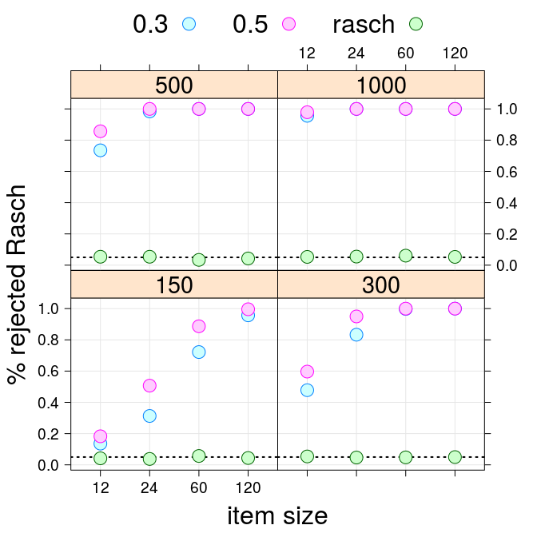

We see that removing items based on infit statistics do not by itself make the data Rasch conform. In fact, in most of the cases, it isn’t! When the true data generating model is the Rasch model, we only make $\alpha$ percent errors. However, when there are overlapping ICCs, even after removal of items based on infit statistics, the Rasch model simply does not hold.

## Appropriate tests

To test for varying item discrimination one would pit the 1PL (Rasch) against the 2PL (Birnbaum) model. We do this by using the package **mirt**.

```r
library('mirt')

mrasch <- mirt(dat, 1, itemtype = 'Rasch', verbose = FALSE)
mbirn <- mirt(dat, 1, itemtype = '2PL', verbose = FALSE)

anova(mrasch, mbirn)
```

```
##
## Model 1: mirt(data = dat, model = 1, itemtype = "Rasch", verbose = FALSE)
## Model 2: mirt(data = dat, model = 1, itemtype = "2PL", verbose = FALSE)
```

```
##        AIC     AICc   SABIC      BIC    logLik       X2  df   p
## 1 65839.46 65847.53 65945.1 66138.84 -32858.73      NaN NaN NaN
## 2 64759.10 64792.14 64966.9 65348.03 -32259.55 1198.364  59   0
```

We find that the 2PL model fits substantially better than the 1PL model.

Until now, not much is gained. It is rather obvious that for assessing slope-invariant ICCs one should test the 1PL against the 2PL model. The 2PL model does not have such nice psychometric properties as the Rasch model. For example, the sum score is no longer a sufficient statistic for a person’s ability. Additionally, specific objectivity does not hold; i.e. it is now relevant on which item two persons are compared. It is therefore quite understandable and reasonable to revise (or throw out) items that cause the 1PL model to fail. In applied settings, specific objectivity and the sum score being a sufficient statistic might be of great importance.

However, coming back to the analogy of the “two schools” of Rasch modeling, researchers need to be aware in which one they are currently attending. Simply throwing out items due to low or high infit is no good. These items might be of theoretical importance, tapping vital parts of the construct scientific reasoning.

Leaving varying item discriminability behind, a more important issue emerges; that of unidimensionality. The central assumption of the Rasch model is that the thing being measured is one-dimensional. In the field of scientific reasoning, this is hard to believe a priori, especially since theories about scientific reasoning **explicitly differentiate four subsets**:

- understanding the nature of science
- understanding theories
- designing experiments
- interpreting data

# II. Violation: Unidimensionality

Here the reductionism in current Rasch modeling becomes apparent. Researchers fit the Rasch model, and look at individual items via infit statistics. Items that are below or above a certain cutoff are removed. Researchers then conclude that since a unidimensional Rasch model provides the best fit, scientific reasoning is a unidimensional construct.

## Specific example

Whe fit a unidimensional Rasch model to the four-dimensional data, specified by sigma (the factor covariance structure) and the item loadings (see sigma and weights above):

```r
items <- 60
wmat <- apply(replicate(items / 4, weights), 2, rbind) # four factors
dat <- sim.xdim(1000, items, Sigma = sigma, weightmat = wmat)

mrasch <- RM(dat)
pp <- person.parameter(mrasch)
eRm::itemfit(pp)
```

```
##
## Itemfit Statistics:
##        Chisq  df p-value Outfit MSQ Infit MSQ Outfit t Infit t
## I1  1010.195 999   0.396      1.010     0.997     0.33   -0.12
## I2   998.398 999   0.499      0.998     0.996    -0.08   -0.27
## I3   973.167 999   0.715      0.973     0.983    -1.10   -0.84
## I4  1026.713 999   0.265      1.027     0.995     0.46   -0.09
## I5   999.068 999   0.493      0.999     0.996    -0.03   -0.21
## I6   999.681 999   0.488      1.000     0.996     0.00   -0.15
## I7   992.479 999   0.552      0.992     0.980    -0.08   -0.29
## I8  1006.491 999   0.428      1.006     1.000     0.14    0.03
## I9   970.881 999   0.732      0.971     0.978    -0.93   -0.84
## I10  955.547 999   0.834      0.956     0.979    -0.82   -0.45
## I11 1000.294 999   0.483      1.000     0.986     0.03   -0.23
## I12  979.088 999   0.668      0.979     0.979    -1.33   -1.49
## I13  996.385 999   0.517      0.996     0.998    -0.12   -0.08
## I14  893.206 999   0.993      0.893     0.957    -1.20   -0.54
## I15  932.567 999   0.934      0.933     0.954    -0.80   -0.62
## I16 1014.285 999   0.361      1.014     1.013     0.28    0.30
## I17  978.339 999   0.674      0.978     0.981    -1.31   -1.26
## I18 1004.035 999   0.449      1.004     1.003     0.18    0.15
## I19  969.049 999   0.746      0.969     0.977    -1.41   -1.21
## I20 1002.670 999   0.461      1.003     0.989     0.06   -0.19
## I21  987.975 999   0.592      0.988     0.987    -0.50   -0.61
## I22 1013.270 999   0.370      1.013     1.009     0.70    0.56
## I23  987.780 999   0.594      0.988     0.990    -0.67   -0.64
## I24 1027.864 999   0.256      1.028     0.987     0.45   -0.22
## I25  962.121 999   0.794      0.962     0.967    -0.61   -0.64
## I26  983.540 999   0.630      0.984     0.987    -0.98   -0.90
## I27  982.497 999   0.639      0.982     0.984    -1.04   -1.04
## I28 1004.555 999   0.445      1.005     1.006     0.21    0.31
## I29  964.936 999   0.775      0.965     0.982    -0.98   -0.60
## I30  988.788 999   0.585      0.989     0.995    -0.40   -0.21
## I31  996.924 999   0.513      0.997     0.983    -0.05   -0.41
## I32 1018.722 999   0.325      1.019     1.012     0.77    0.56
## I33  933.469 999   0.931      0.933     0.973    -0.79   -0.36
## I34 1031.126 999   0.234      1.031     1.028     1.66    1.68
## I35  997.630 999   0.506      0.998     0.997    -0.14   -0.23
## I36 1011.969 999   0.381      1.012     1.006     0.44    0.25
## I37  982.959 999   0.635      0.983     0.984    -1.09   -1.12
```

[output cut: 8 more lines]

```
## I46 1014.024 999   0.363      1.014     1.013     0.70    0.76
## I47 1005.364 999   0.438      1.005     1.002     0.35    0.18
## I48  990.664 999   0.568      0.991     0.998    -0.33   -0.09
## I49 1023.181 999   0.291      1.023     1.017     1.02    0.86
## I50  993.675 999   0.542      0.994     0.994    -0.37   -0.42
## I51  940.822 999   0.905      0.941     0.965    -1.00   -0.70
## I52 1010.578 999   0.392      1.011     1.001     0.18    0.04
## I53  957.695 999   0.822      0.958     0.964    -0.69   -0.70
## I54  974.929 999   0.701      0.975     0.977    -1.00   -1.11
## I55  983.477 999   0.631      0.983     0.988    -0.57   -0.50
## I56 1033.707 999   0.217      1.034     1.011     0.74    0.30
## I57  984.053 999   0.626      0.984     0.990    -0.49   -0.36
## I58  964.521 999   0.778      0.965     0.974    -1.22   -1.07
## I59 1014.561 999   0.359      1.015     1.003     0.41    0.11
## I60 1024.300 999   0.282      1.024     1.025     1.24    1.43
```

When fitting a unidimensional Rasch model to the 4-dimensional data, and inspecting the infit statistics, one finds that they look reasonable; we would not exlude any items. The researcher might be quite happy about this. However, in terms of theory, we are making a grave mistake. We assume that we have a unidimensional construct, when in fact it is four-dimensional! Infit statistics **completely miss the point**.

## Simulation results

```r
sm_mult <- simrasch::summarize(sim_mult)
```

```r
visualize(sm_mult, ylim = c(0, .3))
```

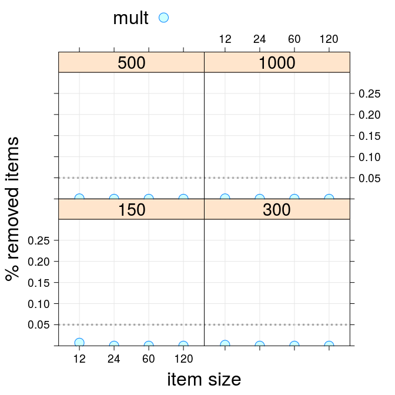

The Martin Loef test is sometimes called a test for unidimensionality. If the Rasch model is true, then all items should measure the same latent variable. Using the knowledge about which items belong to which subscale of scientific reasoning, we can split the items accordingly, and feed this into a Martin Loef test:

```r
MLoef(mrasch, rep(1:4, times = items / 4))
```

```
##
## Martin-Loef-Test (split criterion: user-defined)
## LR-value: 4368.598
## Chi-square df: 65472
## p-value: 1
```

The classical Martin Loef test is not sensitive enough. Thus we rely on an ‘exact’ version as suggested by Koller et al. (2015).

```r
# takes over one hour to run
res <- NPtest(dat, n = 500, method = 'MLoef', splitcr = rep(1:4, items / 4))
```

```r
readRDS('NP_res.RDS') # load the results from disk
```

```
##
## Martin-Loef-Test (split criterion: user-defined)
## LR-value: 4201.277
## Chi-square df: 65472
## p-value: 1
## 'exact' p-value = 0  (based on 500 sampled matrices)
```

We would reject the unidimensional Rasch model based on the exact p-value. In conclusion, although infit statistics would have us believe that nothing is wrong with our unidimentional Rasch model - to be clear, infit doesn’t actually test this; it looks at the items individually - a theoretically motivated, bootstrapped Martin Loef test clearly indicates model misfit.

While the above comparison already would have us reject the unidimensional Rasch model, we can be more specific and theory-driven in our model comparisons. The **mirt** package allows us to specify a model structure that maps our theoretical knowledge about the subscales of scientific reasoning.

```r
model <- 'f1=1, 5, 9, 13, 17, 21, 25, 29, 33, 37, 41, 45, 49, 53, 57
          f2=2, 6, 10, 14, 18, 22, 26, 30, 34, 38, 42, 46, 50, 54, 58
          f3=3, 7, 11, 15, 19, 23, 27, 31, 35, 39, 43, 47, 51, 55, 59
          f4=4, 8, 12, 16, 20, 24, 28, 32, 36, 40, 44, 48, 52, 56, 60
          cov=f1*f2*f3*f4'

fitm <- mirt(dat, 1, itemtype = 'Rasch', verbose = FALSE)
#fit2pl <- mirt(dat, 4, itemtype = '2PL')
```

## Reliability

The reliability of the pseudo one-dimension is

```r
fscores(fitm, returnER = TRUE)
```

```
##        F1
## 0.6252172
```

and is rather low. It is known that when fitting a unidimensional model to multidimensional data that the reliability is low. Most instruments in the literature on scientific thinking show similar low reliability (.5 - .6). Might this represent what is actually happening in the field?

Additionally, by aggregating over different subsets, we loose information, e.g. in terms of criterion validity. If high score on scientific thinking predict say university grades, which facet of scientific thinking is the driving force?

# Conclusion

Item infit statistics were developed for applied Rasch modeling. The adage is that instead of changing our model, we need to change our data because the psychometric properties of the Rasch model are just that good. For applied settings, we would not want to miss out one them!

However, for theory development, solely relying on item infit is detrimental. The current literature on scientific reasoning is beset by tautological testing. Researchers set out to test whether scientific reasoning can be considered unidimensional. They then collect data measuring four theoretically motivated, distinct subsets of scientific reasoning, and fit a Rasch model. Based on item infit statistics, items that do not “fit” - but which might be of theoretical value! - are removed. It is concluded that the Rasch model fits, and thus that scientific reasoning is unidimensional.

We have shown that infit statistics cannot detect multidimensionality. Researchers need to extend their repertoire of tests.

# Suggestions

The Rasch model needs strong theory, and needs to be battle tested. As a case in point, researchers do not usually assess differential item functioning. For example, it seems perfectly reasonable that children in different school classes would solve items differently, which would violate a central assumption of the Rasch model. An easy test would be the Andersen’s Likelihood ratio test, splitting groups according to class; or even better, recursive partitioning (Strobl et al., 2013). Koller et al. (2015) also implemented non-parametric versions thereof which are more appropriate when sample size is small.

There is a repertoire of tests, already implemented in R. We suggest that researchers take a look:

- Andersen test (Andersen, 1973) **[eRm]**
- Martin Löf test (Christensen et al., 2002) **[eRm]**
- Recursive Partitioning (Strobl et al., 2013) **[psychotree]**
- M2 statistic (Maydeu-Olivares, 2013) **[mirt]**
- Nonparametric statistics (Koller et al., 2015) **[eRm]**
- Bayesian posterior predictive checking (Fox, 2010; Sinharay, 2006)
- SEM-like statistics (Maydeu-Olivares, 2014) **[mirt]**